# Optimal Treatment Analysis

## Outcome Variable

**Outcome Variable:** whz

## Predictor Variables

**Intervention Variable:** perdiar24

**Adjustment Set:**

- arm
- sex
- meducyrs
- feducyrs
- hhwealth_quart
- hfoodsec
- vagbrth
- hdlvry
- W_birthwt
- W_birthlen
- single
- W_nrooms
- month
- brthmon
- impfloor
- impsan
- safeh20
- delta_meducyrs
- delta_feducyrs
- delta_hhwealth_quart
- delta_hfoodsec
- delta_vagbrth
- delta_hdlvry
- delta_W_birthwt
- delta_W_birthlen
- delta_single
- delta_W_nrooms
- delta_month
- delta_brthmon
- delta_impfloor
- delta_impsan
- delta_safeh20

## Stratifying Variables

The analysis was stratified on these variable(s):

- agecat
- studyid
- country

## Data Summary

| agecat | studyid | country | perdiar24 | n_cell | n |
| --- | --- | --- | --- | --- | --- |
| Birth | ki0047075b-MAL-ED | BANGLADESH | 0% | 14 | 215 |
| Birth | ki0047075b-MAL-ED | BANGLADESH | (0%, 5%] | 127 | 215 |
| Birth | ki0047075b-MAL-ED | BANGLADESH | >5% | 74 | 215 |
| Birth | ki0047075b-MAL-ED | BRAZIL | 0% | 34 | 62 |
| Birth | ki0047075b-MAL-ED | BRAZIL | (0%, 5%] | 26 | 62 |
| Birth | ki0047075b-MAL-ED | BRAZIL | >5% | 2 | 62 |
| Birth | ki0047075b-MAL-ED | INDIA | 0% | 5 | 45 |
| Birth | ki0047075b-MAL-ED | INDIA | (0%, 5%] | 31 | 45 |
| Birth | ki0047075b-MAL-ED | INDIA | >5% | 9 | 45 |
| Birth | ki0047075b-MAL-ED | NEPAL | 0% | 2 | 26 |
| Birth | ki0047075b-MAL-ED | NEPAL | (0%, 5%] | 19 | 26 |
| Birth | ki0047075b-MAL-ED | NEPAL | >5% | 5 | 26 |
| Birth | ki0047075b-MAL-ED | PERU | 0% | 21 | 228 |
| Birth | ki0047075b-MAL-ED | PERU | (0%, 5%] | 87 | 228 |
| Birth | ki0047075b-MAL-ED | PERU | >5% | 120 | 228 |
| Birth | ki0047075b-MAL-ED | SOUTH AFRICA | 0% | 42 | 112 |
| Birth | ki0047075b-MAL-ED | SOUTH AFRICA | (0%, 5%] | 69 | 112 |
| Birth | ki0047075b-MAL-ED | SOUTH AFRICA | >5% | 1 | 112 |
| Birth | ki0047075b-MAL-ED | TANZANIA, UNITED REPUBLIC OF | 0% | 7 | 115 |
| Birth | ki0047075b-MAL-ED | TANZANIA, UNITED REPUBLIC OF | (0%, 5%] | 77 | 115 |
| Birth | ki0047075b-MAL-ED | TANZANIA, UNITED REPUBLIC OF | >5% | 31 | 115 |
| Birth | ki1000109-EE | PAKISTAN | 0% | 115 | 177 |
| Birth | ki1000109-EE | PAKISTAN | (0%, 5%] | 62 | 177 |
| Birth | ki1000109-EE | PAKISTAN | >5% | 0 | 177 |
| Birth | ki1017093-NIH-Birth | BANGLADESH | 0% | 46 | 572 |
| Birth | ki1017093-NIH-Birth | BANGLADESH | (0%, 5%] | 327 | 572 |
| Birth | ki1017093-NIH-Birth | BANGLADESH | >5% | 199 | 572 |
| Birth | ki1017093b-PROVIDE | BANGLADESH | 0% | 55 | 532 |
| Birth | ki1017093b-PROVIDE | BANGLADESH | (0%, 5%] | 322 | 532 |
| Birth | ki1017093b-PROVIDE | BANGLADESH | >5% | 155 | 532 |

[output cut: 102 more lines]

The following strata were considered:

- agecat: 24 months, studyid: ki0047075b-MAL-ED, country: BANGLADESH
- agecat: 24 months, studyid: ki0047075b-MAL-ED, country: BRAZIL
- agecat: 24 months, studyid: ki0047075b-MAL-ED, country: INDIA
- agecat: 24 months, studyid: ki0047075b-MAL-ED, country: NEPAL
- agecat: 24 months, studyid: ki0047075b-MAL-ED, country: PERU
- agecat: 24 months, studyid: ki0047075b-MAL-ED, country: SOUTH AFRICA
- agecat: 24 months, studyid: ki0047075b-MAL-ED, country: TANZANIA, UNITED REPUBLIC OF
- agecat: 24 months, studyid: ki1000109-EE, country: PAKISTAN
- agecat: 24 months, studyid: ki1017093-NIH-Birth, country: BANGLADESH
- agecat: 24 months, studyid: ki1017093b-PROVIDE, country: BANGLADESH
- agecat: 24 months, studyid: ki1017093c-NIH-Crypto, country: BANGLADESH
- agecat: 24 months, studyid: ki1114097-CMIN, country: BANGLADESH
- agecat: 24 months, studyid: ki1114097-CONTENT, country: PERU
- agecat: 24 months, studyid: kiGH5241-JiVitA-4, country: BANGLADESH
- agecat: 6 months, studyid: ki0047075b-MAL-ED, country: BANGLADESH
- agecat: 6 months, studyid: ki0047075b-MAL-ED, country: BRAZIL
- agecat: 6 months, studyid: ki0047075b-MAL-ED, country: INDIA
- agecat: 6 months, studyid: ki0047075b-MAL-ED, country: NEPAL
- agecat: 6 months, studyid: ki0047075b-MAL-ED, country: PERU
- agecat: 6 months, studyid: ki0047075b-MAL-ED, country: SOUTH AFRICA
- agecat: 6 months, studyid: ki0047075b-MAL-ED, country: TANZANIA, UNITED REPUBLIC OF
- agecat: 6 months, studyid: ki1000109-EE, country: PAKISTAN
- agecat: 6 months, studyid: ki1000304b-SAS-FoodSuppl, country: INDIA
- agecat: 6 months, studyid: ki1017093-NIH-Birth, country: BANGLADESH
- agecat: 6 months, studyid: ki1017093b-PROVIDE, country: BANGLADESH
- agecat: 6 months, studyid: ki1017093c-NIH-Crypto, country: BANGLADESH
- agecat: 6 months, studyid: ki1112895-Guatemala BSC, country: GUATEMALA
- agecat: 6 months, studyid: ki1114097-CMIN, country: BANGLADESH
- agecat: 6 months, studyid: ki1114097-CONTENT, country: PERU
- agecat: 6 months, studyid: kiGH5241-JiVitA-4, country: BANGLADESH
- agecat: Birth, studyid: ki0047075b-MAL-ED, country: BANGLADESH
- agecat: Birth, studyid: ki0047075b-MAL-ED, country: BRAZIL
- agecat: Birth, studyid: ki0047075b-MAL-ED, country: INDIA
- agecat: Birth, studyid: ki0047075b-MAL-ED, country: NEPAL
- agecat: Birth, studyid: ki0047075b-MAL-ED, country: PERU
- agecat: Birth, studyid: ki0047075b-MAL-ED, country: SOUTH AFRICA
- agecat: Birth, studyid: ki0047075b-MAL-ED, country: TANZANIA, UNITED REPUBLIC OF
- agecat: Birth, studyid: ki1000109-EE, country: PAKISTAN
- agecat: Birth, studyid: ki1017093-NIH-Birth, country: BANGLADESH
- agecat: Birth, studyid: ki1017093b-PROVIDE, country: BANGLADESH
- agecat: Birth, studyid: ki1017093c-NIH-Crypto, country: BANGLADESH
- agecat: Birth, studyid: ki1114097-CMIN, country: BANGLADESH
- agecat: Birth, studyid: ki1114097-CONTENT, country: PERU
- agecat: Birth, studyid: kiGH5241-JiVitA-4, country: BANGLADESH

### Dropped Strata

Some strata were dropped due to rare outcomes:

- agecat: Birth, studyid: ki0047075b-MAL-ED, country: BRAZIL
- agecat: Birth, studyid: ki0047075b-MAL-ED, country: NEPAL
- agecat: Birth, studyid: ki0047075b-MAL-ED, country: SOUTH AFRICA
- agecat: Birth, studyid: ki1000109-EE, country: PAKISTAN
- agecat: Birth, studyid: ki1114097-CMIN, country: BANGLADESH
- agecat: Birth, studyid: ki1114097-CONTENT, country: PERU
- agecat: 6 months, studyid: ki0047075b-MAL-ED, country: BRAZIL
- agecat: 6 months, studyid: ki0047075b-MAL-ED, country: INDIA
- agecat: 6 months, studyid: ki0047075b-MAL-ED, country: SOUTH AFRICA
- agecat: 6 months, studyid: ki1000109-EE, country: PAKISTAN
- agecat: 6 months, studyid: ki1114097-CMIN, country: BANGLADESH
- agecat: 24 months, studyid: ki0047075b-MAL-ED, country: BRAZIL
- agecat: 24 months, studyid: ki0047075b-MAL-ED, country: INDIA
- agecat: 24 months, studyid: ki0047075b-MAL-ED, country: PERU
- agecat: 24 months, studyid: ki0047075b-MAL-ED, country: SOUTH AFRICA
- agecat: 24 months, studyid: ki1000109-EE, country: PAKISTAN
- agecat: 24 months, studyid: ki1114097-CMIN, country: BANGLADESH
- agecat: 24 months, studyid: ki1114097-CONTENT, country: PERU

## Methods Detail

We’re interested in the causal parameters $E[Y_a]$ for all values of $a \in \mathcal{A}$. These parameters represent the mean outcome if, possibly contrary to fact, we intervened to set all units to have $A=a$. Under the randomization and positivity assumptions, these are identified by the statistical parameters $\psi_a=E_W[E_{Y|A,W}(Y|A=a,W)]$. In addition, we’re interested in the mean of $Y$, $E[Y]$ under no intervention (the observed mean). We will estimate these parameters by using SuperLearner to fit the relevant likelihood factors – $E_{Y|A,W}(Y|A=a,W)$ and $p(A=a|W)$, and then updating our likelihood fit using a joint TMLE.

For unadjusted analyses ($W=\{\}$), initial likelihoods were estimated using Lrnr_glm to estimate the simple $E(Y|A)$ and Lrnr_mean to estimate $p(A)$. For adjusted analyses, a small library containing Lrnr_glmnet, Lrnr_xgboost, and Lrnr_mean was used.

# Results Detail

## Results Plots

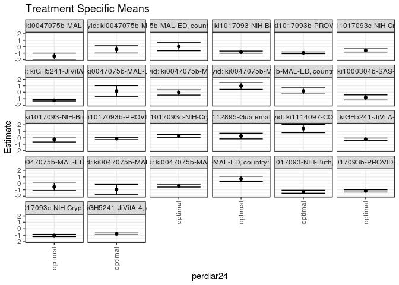

## Results Table

### Parameter: TSM

| agecat | studyid | country | intervention_level | baseline_level | estimate | ci_lower | ci_upper |
| --- | --- | --- | --- | --- | --- | --- | --- |
| Birth | ki0047075b-MAL-ED | BANGLADESH | optimal | observed | -0.5485681 | -1.1278003 | 0.0306640 |
| Birth | ki0047075b-MAL-ED | INDIA | optimal | observed | -0.9400206 | -1.7015416 | -0.1784996 |
| Birth | ki0047075b-MAL-ED | PERU | optimal | observed | -0.3996338 | -0.5841593 | -0.2151083 |
| Birth | ki0047075b-MAL-ED | TANZANIA, UNITED REPUBLIC OF | optimal | observed | 0.6950821 | 0.2906038 | 1.0995604 |
| Birth | ki1017093-NIH-Birth | BANGLADESH | optimal | observed | -1.3070617 | -1.5355814 | -1.0785419 |
| Birth | ki1017093b-PROVIDE | BANGLADESH | optimal | observed | -1.1817487 | -1.3588129 | -1.0046845 |
| Birth | ki1017093c-NIH-Crypto | BANGLADESH | optimal | observed | -1.0335985 | -1.2090365 | -0.8581605 |
| Birth | kiGH5241-JiVitA-4 | BANGLADESH | optimal | observed | -0.7836463 | -0.9176341 | -0.6496584 |
| 6 months | ki0047075b-MAL-ED | BANGLADESH | optimal | observed | 0.1949583 | -0.6238594 | 1.0137760 |
| 6 months | ki0047075b-MAL-ED | NEPAL | optimal | observed | -0.0300335 | -0.4337381 | 0.3736712 |
| 6 months | ki0047075b-MAL-ED | PERU | optimal | observed | 0.9708476 | 0.4500243 | 1.4916709 |
| 6 months | ki0047075b-MAL-ED | TANZANIA, UNITED REPUBLIC OF | optimal | observed | 0.2029346 | -0.2693906 | 0.6752598 |
| 6 months | ki1000304b-SAS-FoodSuppl | INDIA | optimal | observed | -0.7974436 | -1.1915968 | -0.4032905 |
| 6 months | ki1017093-NIH-Birth | BANGLADESH | optimal | observed | -0.2655134 | -0.6520871 | 0.1210603 |
| 6 months | ki1017093b-PROVIDE | BANGLADESH | optimal | observed | -0.1286884 | -0.2765462 | 0.0191694 |
| 6 months | ki1017093c-NIH-Crypto | BANGLADESH | optimal | observed | 0.2908644 | 0.0823865 | 0.4993422 |
| 6 months | ki1112895-Guatemala BSC | GUATEMALA | optimal | observed | 0.2687994 | -0.1664438 | 0.7040426 |
| 6 months | ki1114097-CONTENT | PERU | optimal | observed | 1.4165919 | 0.7840601 | 2.0491237 |
| 6 months | kiGH5241-JiVitA-4 | BANGLADESH | optimal | observed | -0.2147842 | -0.3871065 | -0.0424618 |
| 24 months | ki0047075b-MAL-ED | BANGLADESH | optimal | observed | -1.4634793 | -1.9318557 | -0.9951030 |
| 24 months | ki0047075b-MAL-ED | NEPAL | optimal | observed | -0.4085907 | -0.9799005 | 0.1627191 |
| 24 months | ki0047075b-MAL-ED | TANZANIA, UNITED REPUBLIC OF | optimal | observed | 0.0371225 | -0.6228158 | 0.6970608 |
| 24 months | ki1017093-NIH-Birth | BANGLADESH | optimal | observed | -0.8369239 | -1.0010540 | -0.6727937 |
| 24 months | ki1017093b-PROVIDE | BANGLADESH | optimal | observed | -0.9365241 | -1.0706641 | -0.8023841 |
| 24 months | ki1017093c-NIH-Crypto | BANGLADESH | optimal | observed | -0.5644630 | -0.8168674 | -0.3120586 |
| 24 months | kiGH5241-JiVitA-4 | BANGLADESH | optimal | observed | -1.2272014 | -1.3427928 | -1.1116100 |

### Parameter: E(Y)

| agecat | studyid | country | intervention_level | baseline_level | estimate | ci_lower | ci_upper |
| --- | --- | --- | --- | --- | --- | --- | --- |
| Birth | ki0047075b-MAL-ED | BANGLADESH | observed | observed | -0.9418605 | -1.0869834 | -0.7967375 |
| Birth | ki0047075b-MAL-ED | INDIA | observed | observed | -0.9324444 | -1.2067907 | -0.6580982 |
| Birth | ki0047075b-MAL-ED | PERU | observed | observed | -0.0520175 | -0.1725298 | 0.0684947 |
| Birth | ki0047075b-MAL-ED | TANZANIA, UNITED REPUBLIC OF | observed | observed | 0.7624348 | 0.5710709 | 0.9537986 |
| Birth | ki1017093-NIH-Birth | BANGLADESH | observed | observed | -1.3525437 | -1.4473932 | -1.2576942 |
| Birth | ki1017093b-PROVIDE | BANGLADESH | observed | observed | -1.2984586 | -1.3752758 | -1.2216415 |
| Birth | ki1017093c-NIH-Crypto | BANGLADESH | observed | observed | -1.2441513 | -1.3281130 | -1.1601897 |
| Birth | kiGH5241-JiVitA-4 | BANGLADESH | observed | observed | -0.6886269 | -0.7410452 | -0.6362086 |
| 6 months | ki0047075b-MAL-ED | BANGLADESH | observed | observed | -0.1376763 | -0.2664642 | -0.0088885 |
| 6 months | ki0047075b-MAL-ED | NEPAL | observed | observed | 0.1104308 | -0.0208643 | 0.2417259 |
| 6 months | ki0047075b-MAL-ED | PERU | observed | observed | 1.0528816 | 0.9313005 | 1.1744626 |
| 6 months | ki0047075b-MAL-ED | TANZANIA, UNITED REPUBLIC OF | observed | observed | 0.5362213 | 0.4049390 | 0.6675036 |
| 6 months | ki1000304b-SAS-FoodSuppl | INDIA | observed | observed | -1.0121579 | -1.1280429 | -0.8962729 |
| 6 months | ki1017093-NIH-Birth | BANGLADESH | observed | observed | -0.4474038 | -0.5378167 | -0.3569909 |
| 6 months | ki1017093b-PROVIDE | BANGLADESH | observed | observed | -0.1990907 | -0.2817968 | -0.1163845 |
| 6 months | ki1017093c-NIH-Crypto | BANGLADESH | observed | observed | 0.0297622 | -0.0491685 | 0.1086930 |
| 6 months | ki1112895-Guatemala BSC | GUATEMALA | observed | observed | -0.0840134 | -0.1945572 | 0.0265305 |
| 6 months | ki1114097-CONTENT | PERU | observed | observed | 1.0684318 | 0.9515274 | 1.1853362 |
| 6 months | kiGH5241-JiVitA-4 | BANGLADESH | observed | observed | -0.3898055 | -0.4270507 | -0.3525603 |
| 24 months | ki0047075b-MAL-ED | BANGLADESH | observed | observed | -0.8192925 | -0.9412667 | -0.6973182 |
| 24 months | ki0047075b-MAL-ED | NEPAL | observed | observed | -0.3749123 | -0.4886073 | -0.2612173 |
| 24 months | ki0047075b-MAL-ED | TANZANIA, UNITED REPUBLIC OF | observed | observed | 0.0547975 | -0.0703378 | 0.1799328 |
| 24 months | ki1017093-NIH-Birth | BANGLADESH | observed | observed | -0.9115790 | -1.0095022 | -0.8136559 |
| 24 months | ki1017093b-PROVIDE | BANGLADESH | observed | observed | -0.8928670 | -0.9755153 | -0.8102187 |
| 24 months | ki1017093c-NIH-Crypto | BANGLADESH | observed | observed | -0.6103502 | -0.7050157 | -0.5156847 |
| 24 months | kiGH5241-JiVitA-4 | BANGLADESH | observed | observed | -1.2231088 | -1.2549632 | -1.1912543 |

### Parameter: PAR

| agecat | studyid | country | intervention_level | baseline_level | estimate | ci_lower | ci_upper |
| --- | --- | --- | --- | --- | --- | --- | --- |
| Birth | ki0047075b-MAL-ED | BANGLADESH | optimal | observed | -0.3932923 | -0.9538400 | 0.1672553 |
| Birth | ki0047075b-MAL-ED | INDIA | optimal | observed | 0.0075761 | -0.6700540 | 0.6852063 |
| Birth | ki0047075b-MAL-ED | PERU | optimal | observed | 0.3476162 | 0.1613311 | 0.5339013 |
| Birth | ki0047075b-MAL-ED | TANZANIA, UNITED REPUBLIC OF | optimal | observed | 0.0673527 | -0.3273616 | 0.4620670 |
| Birth | ki1017093-NIH-Birth | BANGLADESH | optimal | observed | -0.0454820 | -0.2658632 | 0.1748991 |
| Birth | ki1017093b-PROVIDE | BANGLADESH | optimal | observed | -0.1167099 | -0.2852085 | 0.0517887 |
| Birth | ki1017093c-NIH-Crypto | BANGLADESH | optimal | observed | -0.2105528 | -0.3672696 | -0.0538361 |
| Birth | kiGH5241-JiVitA-4 | BANGLADESH | optimal | observed | 0.0950194 | -0.0274370 | 0.2174758 |
| 6 months | ki0047075b-MAL-ED | BANGLADESH | optimal | observed | -0.3326346 | -1.1420060 | 0.4767367 |
| 6 months | ki0047075b-MAL-ED | NEPAL | optimal | observed | 0.1404643 | -0.2343687 | 0.5152972 |
| 6 months | ki0047075b-MAL-ED | PERU | optimal | observed | 0.0820339 | -0.4130866 | 0.5771545 |
| 6 months | ki0047075b-MAL-ED | TANZANIA, UNITED REPUBLIC OF | optimal | observed | 0.3332867 | -0.1136878 | 0.7802612 |
| 6 months | ki1000304b-SAS-FoodSuppl | INDIA | optimal | observed | -0.2147143 | -0.5903057 | 0.1608771 |
| 6 months | ki1017093-NIH-Birth | BANGLADESH | optimal | observed | -0.1818904 | -0.5690594 | 0.2052786 |
| 6 months | ki1017093b-PROVIDE | BANGLADESH | optimal | observed | -0.0704023 | -0.1958453 | 0.0550407 |
| 6 months | ki1017093c-NIH-Crypto | BANGLADESH | optimal | observed | -0.2611021 | -0.4568418 | -0.0653625 |
| 6 months | ki1112895-Guatemala BSC | GUATEMALA | optimal | observed | -0.3528128 | -0.7664412 | 0.0608156 |
| 6 months | ki1114097-CONTENT | PERU | optimal | observed | -0.3481601 | -0.9767104 | 0.2803902 |
| 6 months | kiGH5241-JiVitA-4 | BANGLADESH | optimal | observed | -0.1750213 | -0.3410427 | -0.0090000 |
| 24 months | ki0047075b-MAL-ED | BANGLADESH | optimal | observed | 0.6441869 | 0.1753606 | 1.1130131 |
| 24 months | ki0047075b-MAL-ED | NEPAL | optimal | observed | 0.0336784 | -0.5182285 | 0.5855854 |
| 24 months | ki0047075b-MAL-ED | TANZANIA, UNITED REPUBLIC OF | optimal | observed | 0.0176750 | -0.6352879 | 0.6706379 |
| 24 months | ki1017093-NIH-Birth | BANGLADESH | optimal | observed | -0.0746552 | -0.2100989 | 0.0607886 |
| 24 months | ki1017093b-PROVIDE | BANGLADESH | optimal | observed | 0.0436571 | -0.0718476 | 0.1591617 |
| 24 months | ki1017093c-NIH-Crypto | BANGLADESH | optimal | observed | -0.0458872 | -0.2707331 | 0.1789588 |
| 24 months | kiGH5241-JiVitA-4 | BANGLADESH | optimal | observed | 0.0040927 | -0.1034548 | 0.1116402 |